# Trabalho Estatistica

### Equipe:

##### Carlos Alberto Figueiredo - RM330568

##### Daiana Cristina Zanelli Mota - RM330722

##### Diogo Silva Rocha - RM330717

##### Renato Belandrino Rodrigues - RM330579

install.packages(“psych”) install.packages(“plotly”) install.packages(“gmodels”) install.packages(“corrgram”)

```r
# mostrar atÈ 2 casas decimais
options("scipen" = 2)

# Ler arquivo csv


Vinhos <- read.csv2("BaseWineRedeWhite2018.csv", row.names=1)
```

```r
#Vinhos <- BaseWine_Red_e_White2018
#fix(Vinhos)
#mostrar as vari·veis
#str(Vinhos)
#mostra as vari·veis
names(Vinhos)
```

```
##  [1] "fixedacidity"       "volatileacidity"    "citricacid"
##  [4] "residualsugar"      "chlorides"          "freesulfurdioxide"
##  [7] "totalsulfurdioxide" "density"            "pH"
## [10] "sulphates"          "alcohol"            "quality"
## [13] "Vinho"
```

```r
#XX Variáveis e muita informação
```

```r
attach(Vinhos)

# FrequÍncia absoluta
table(as.factor(Vinhos$quality), Vinhos$Vinho, useNA = "ifany")
```

```
##
##      RED WHITE
##   3   10    20
##   4   53   163
##   5  681  1457
##   6  638  2198
##   7  199   880
##   8   18   175
##   9    0     5
```

```r
table(as.factor(Vinhos$quality), Vinhos$Vinho)
```

```
##
##      RED WHITE
##   3   10    20
##   4   53   163
##   5  681  1457
##   6  638  2198
##   7  199   880
##   8   18   175
##   9    0     5
```

Análise:

Avaliando as duas tabelas de frequência das notas/qualiade que comparam os vinhos tintos e brancos, vemos que não exsitem valores “brancos/NA” já que as duas tabelas apresentam as mesmas frequências.

Olhando os valores entre as duas tabelas, testamos a hipótese da resposta de qualidade ser diverente entre os vinhos Brancos e Tintos. Para isso fizemos um Teste para duas amostras

```r
Quality <- split(Vinhos, Vinhos$Vinho)

t.test(Quality$WHITE$quality, Quality$RED$quality)
```

```
##
##  Welch Two Sample t-test
##
## data:  Quality$WHITE$quality and Quality$RED$quality
## t = 10.149, df = 2950.8, p-value < 2.2e-16
## alternative hypothesis: true difference in means is not equal to 0
## 95 percent confidence interval:
##  0.1951564 0.2886173
## sample estimates:
## mean of x mean of y
##  5.877909  5.636023
```

Análise:

A partir do valor do p-value e risco alfa máximo de 5%, podemos dizer que os vinhos Brancos e Tintos tem valores médios de notas diferentes, já que o p-value < 2.2e-16

```r
# 2-Way Cross Tabulation
library(gmodels)
CrossTable(as.factor(Vinhos$quality), Vinhos$Vinho)
```

```
##
##
##    Cell Contents
## |-------------------------|
## |                       N |
## | Chi-square contribution |
## |           N / Row Total |
## |           N / Col Total |
## |         N / Table Total |
## |-------------------------|
##
##
## Total Observations in Table:  6497
##
##
##                           | Vinhos$Vinho
## as.factor(Vinhos$quality) |       RED |     WHITE | Row Total |
## --------------------------|-----------|-----------|-----------|
##                         3 |        10 |        20 |        30 |
##                           |     0.927 |     0.303 |           |
##                           |     0.333 |     0.667 |     0.005 |
##                           |     0.006 |     0.004 |           |
##                           |     0.002 |     0.003 |           |
## --------------------------|-----------|-----------|-----------|
##                         4 |        53 |       163 |       216 |
##                           |     0.000 |     0.000 |           |
##                           |     0.245 |     0.755 |     0.033 |
##                           |     0.033 |     0.033 |           |
##                           |     0.008 |     0.025 |           |
## --------------------------|-----------|-----------|-----------|
##                         5 |       681 |      1457 |      2138 |
##                           |    45.546 |    14.869 |           |
##                           |     0.319 |     0.681 |     0.329 |
##                           |     0.426 |     0.297 |           |
##                           |     0.105 |     0.224 |           |
## --------------------------|-----------|-----------|-----------|
##                         6 |       638 |      2198 |      2836 |
##                           |     5.154 |     1.683 |           |
##                           |     0.225 |     0.775 |     0.437 |
##                           |     0.399 |     0.449 |           |
```

[output cut: 10 more lines]

```
##                           |     0.093 |     0.907 |     0.030 |
##                           |     0.011 |     0.036 |           |
##                           |     0.003 |     0.027 |           |
## --------------------------|-----------|-----------|-----------|
##                         9 |         0 |         5 |         5 |
##                           |     1.231 |     0.402 |           |
##                           |     0.000 |     1.000 |     0.001 |
##                           |     0.000 |     0.001 |           |
##                           |     0.000 |     0.001 |           |
## --------------------------|-----------|-----------|-----------|
##              Column Total |      1599 |      4898 |      6497 |
##                           |     0.246 |     0.754 |           |
## --------------------------|-----------|-----------|-----------|
##
##
```

Análise:

A partir da tabela cruzada entre tipo do vinho (Branco e Tinto) e as notas de qualidade, podemos perceber a maior frequencia geral é de notas 6 (43,7%).

Mas olhando para cada tipo de vinho individualmente, a nota 6 é mais frequente para o vinho branco(44,9%), enquanto a nota mais frenquente para o vinho tinto é 5 (42,6%), o que ajuda a confirmar a diferença entre os vinhos, com relação as notas de qualidade.

```r
summary(Vinhos)
```

```
##   fixedacidity    volatileacidity    citricacid     residualsugar
##  Min.   : 3.800   Min.   :0.0800   Min.   :0.0000   Min.   : 0.60
##  1st Qu.: 6.400   1st Qu.:0.2300   1st Qu.:0.2500   1st Qu.: 1.80
##  Median : 7.000   Median :0.2900   Median :0.3100   Median : 3.00
##  Mean   : 7.215   Mean   :0.3397   Mean   :0.3186   Mean   : 5.44
##  3rd Qu.: 7.700   3rd Qu.:0.4000   3rd Qu.:0.3900   3rd Qu.: 8.10
##  Max.   :15.900   Max.   :1.5800   Max.   :1.6600   Max.   :45.80
##    chlorides       freesulfurdioxide totalsulfurdioxide    density
##  Min.   :0.00900   Min.   :  1.00    Min.   :  6.0      Min.   :0.9871
##  1st Qu.:0.03800   1st Qu.: 17.00    1st Qu.: 77.0      1st Qu.:0.9923
##  Median :0.04700   Median : 29.00    Median :118.0      Median :0.9949
##  Mean   :0.05603   Mean   : 30.53    Mean   :115.7      Mean   :0.9947
##  3rd Qu.:0.06500   3rd Qu.: 41.00    3rd Qu.:156.0      3rd Qu.:0.9970
##  Max.   :0.61100   Max.   :289.00    Max.   :440.0      Max.   :1.0140
##        pH          sulphates         alcohol           quality
##  Min.   :2.720   Min.   :0.2200   Min.   : 0.9567   Min.   :3.000
##  1st Qu.:3.110   1st Qu.:0.4300   1st Qu.: 9.5000   1st Qu.:5.000
##  Median :3.210   Median :0.5100   Median :10.3000   Median :6.000
##  Mean   :3.219   Mean   :0.5313   Mean   :10.4862   Mean   :5.818
##  3rd Qu.:3.320   3rd Qu.:0.6000   3rd Qu.:11.3000   3rd Qu.:6.000
##  Max.   :4.010   Max.   :2.0000   Max.   :14.9000   Max.   :9.000
##    Vinho
##  RED  :1599
##  WHITE:4898
##
##
##
##
```

Análise:

```r
aggregate (Vinhos,
           by = list(Vinho),
           FUN =  "mean")
```

```
##   Group.1 fixedacidity volatileacidity citricacid residualsugar  chlorides
## 1     RED     8.319637       0.5278205  0.2709756      2.538806 0.08746654
## 2   WHITE     6.854788       0.2782411  0.3341915      6.387332 0.04577236
##   freesulfurdioxide totalsulfurdioxide   density       pH sulphates
## 1          15.87492           46.46779 0.9967467 3.311113 0.6581488
## 2          35.30808          138.36066 0.9940223 3.188267 0.4898469
##    alcohol  quality Vinho
## 1 10.40008 5.636023    NA
## 2 10.51427 5.877909    NA
```

Análise:

Função retorna a media de todas as vaiáveis numéricas para os vinhos Brancos e Tintos Pontos que chamam a atenção:

- residualsugar é muito maior para os brancos apesar do alcohol ter valores próximos.
- freesulfurdioxide e totalsulfurdioxide é maior nos vinhos brancos que nos tintos. Este conservante também serve para previnir o escurecimento dos vinhos. Por isso, talvez, sua maior concentração nos Brancos.

O cometário “argument is not numeric or logical: returning NAargument is not numeric or logical: returning NA” é devido a variável vinho que não é numérica

```r
mean(Vinhos$fixedacidity) # mÈdia
```

```
## [1] 7.215307
```

```r
median(Vinhos$fixedacidity) # mÈdiana
```

```
## [1] 7
```

```r
quantile(Vinhos$fixedacidity,type=4)  # Quartis
```

```
##   0%  25%  50%  75% 100%
##  3.8  6.4  7.0  7.7 15.9
```

```r
quantile(Vinhos$fixedacidity,.65,type=4) # exato percentil
```

```
## 65%
## 7.3
```

```r
range(Vinhos$fixedacidity)  # amplitude
```

```
## [1]  3.8 15.9
```

```r
diff(range(Vinhos$fixedacidity)) #diferenÁa entre o maior e o menor valor
```

```
## [1] 12.1
```

```r
min(Vinhos$fixedacidity)  # valor mÌnimo de x
```

```
## [1] 3.8
```

```r
max(Vinhos$fixedacidity)  # valor m·ximo de x
```

```
## [1] 15.9
```

```r
var(Vinhos$fixedacidity) # para obter a vari‚ncia
```

```
## [1] 1.68074
```

```r
sd(Vinhos$fixedacidity)  # para obter o desvio padr„o
```

```
## [1] 1.296434
```

```r
CV_fixedacidity<-sd(Vinhos$fixedacidity)/mean(Vinhos$fixedacidity)*100  # para obter o coefiiente de variaÁ„o
CV_fixedacidity
```

```
## [1] 17.96783
```

Análise:

As funções retornam estaísticas decritivas para a variavel fixedacidity, inclusive o Coeficiente de Variação (CV).

CV = Em teoria das probabilidades e estatística, o coeficiente de variação (CV), também conhecido como desvio padrão relativo (DPR), é uma medida padronizada de dispersão de uma distribuição de probabilidade ou de uma distribuição de frequências. É frequentemente expresso como uma porcentagem, sendo definido como a razão do desvio padrão pela média (ou seu valor absoluto. O CV ou DPR é amplamente usado em química analítica para expressar a precisão e a repetitividade de um ensaio. Também é comumente usado em campos como engenharia e física quando se fazem estudos de garantia de qualidade e avaliações de repetitividade e reprodutibilidade. O CV também é usado por economistas e investidores em modelos econômicos e na determinação da volatilidade de um valor mobiliário. Fonte: Wikipédia

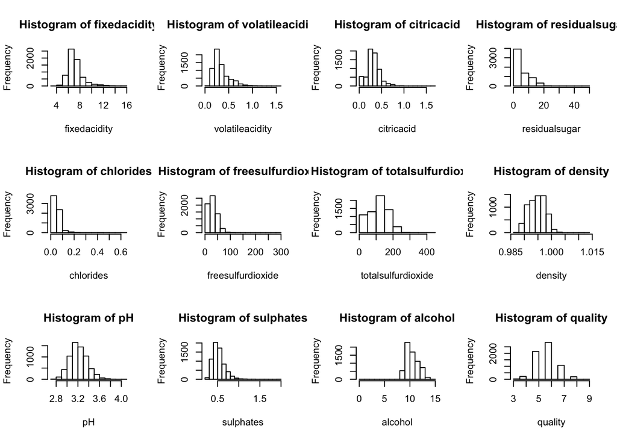

```r
#comando para gerar em 3 linhas e 4 colunas os histogramas
par (mfrow=c(3,4))
hist(fixedacidity)
hist(volatileacidity)
hist(citricacid )
hist(residualsugar)
hist(chlorides)
hist(freesulfurdioxide)
hist(totalsulfurdioxide)
hist(density)
hist(pH)
hist(sulphates)
hist(alcohol)
hist(quality)
```

Análise:

Avaliando os histogrmas, alguns pontos chamam a atenção:

- As escalas estão bem abertas, indicando a presença de Outliers, principalmente para: volatileacidity, citricacid, chlorides, freesulfurdioxide
- Distribuições assimetricas, com mínimos limitados pelo valor zero, por exemplo: volatileacidity, residualsugar, chlorides, freesulfurdioxide

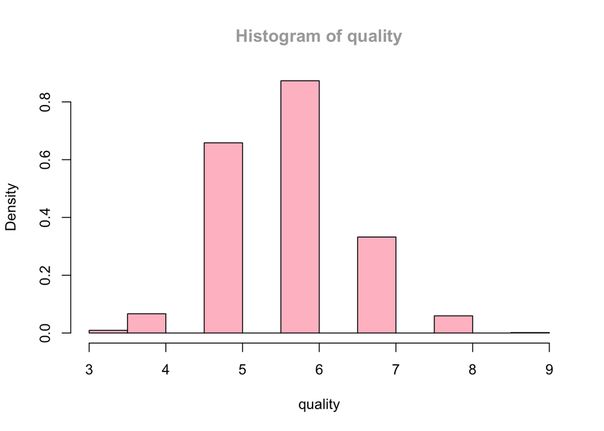

```r
hist(quality, col=c("pink"), col.main="darkgray", prob=T)
```

Análise:

- O histograma da quality, por ter valores inteiros, o histograma parece “dentado” mas que não invalida a análise de uma distribuição simétrica, possivelmente Normal

```r
attach(Vinhos)
```

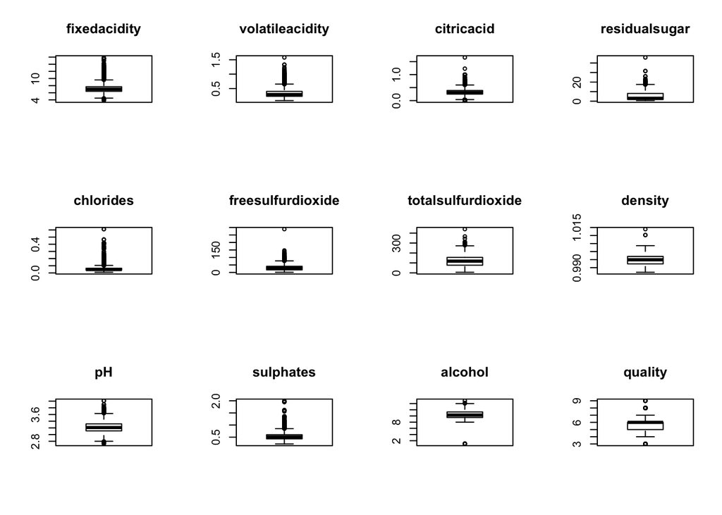

```r
#comando para gerar em 3 linhas e 4 colunas os histogramas
par (mfrow=c(3,4))
boxplot(fixedacidity, main='fixedacidity')
boxplot(volatileacidity , main='volatileacidity')
boxplot(citricacid , main='citricacid')
boxplot(residualsugar, main='residualsugar')
boxplot(chlorides, main='chlorides')
boxplot(freesulfurdioxide, main='freesulfurdioxide')
boxplot(totalsulfurdioxide, main='totalsulfurdioxide')
boxplot(density, main='density')
boxplot(pH, main='pH')
boxplot(sulphates, main='sulphates')
boxplot(alcohol, main='alcohol')
boxplot(Vinhos$quality, main='quality')
```

Análise:

As análises dos Box Plots validam as que já fizemos para os histogramas.

Apesar de todos os Box Plots apresentarem Outliers, que pode ser efeito dos tamanhos de amostra, os BoxPlots com maiores quantidade de outliers são: volatileacidity, citricacid, chlorides, freesulfurdioxide. citricacid, freesulfurdioxide e alcohol com valores pontuais bem distantes da distribuição. Valeria uma melhor avaliação destes pontos de medidas para verificação se realmente são pontos fora da curva esperada.

Distribuições assimetricas, com principal atenção para residualsugar, onde a assimentria se destaca na forma da caixa de dos bigodes do Box Plot. Mediana deslocada para o Q1 e bigode inferior bem menor que o superior.

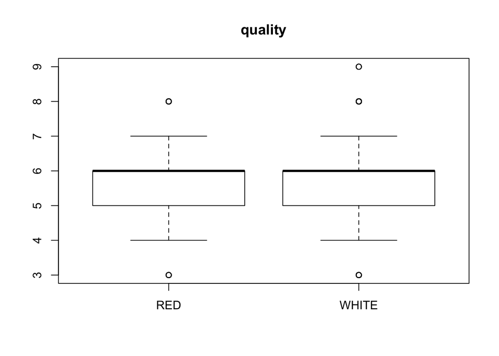

```r
boxplot(quality ~ Vinho, main='quality')
```

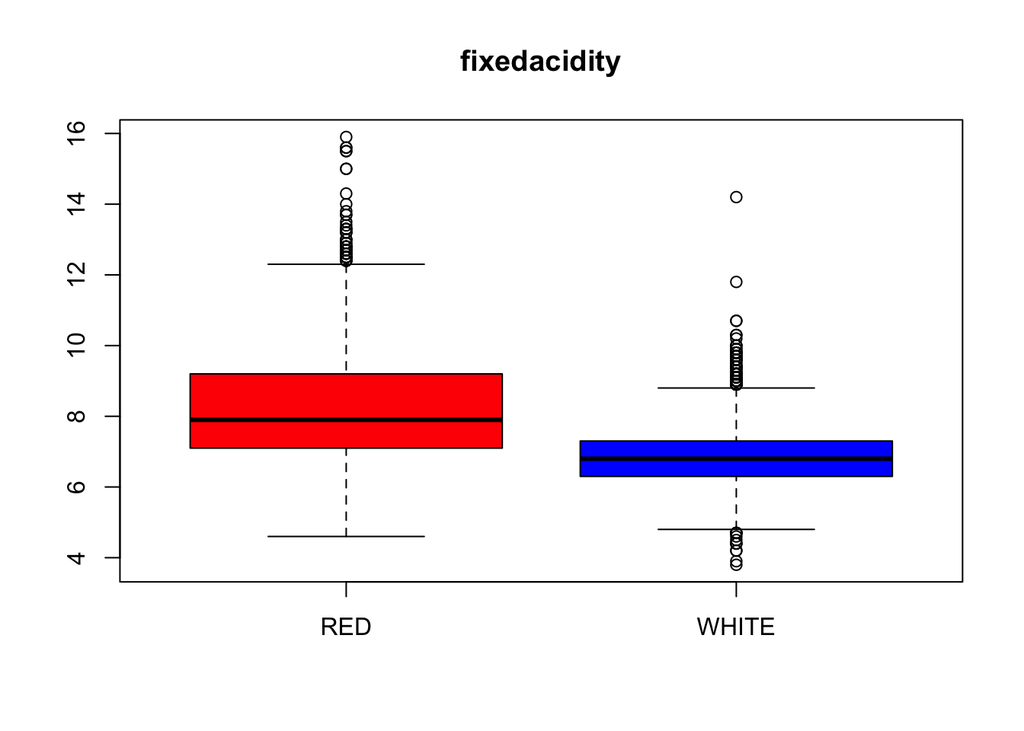

```r
boxplot(fixedacidity ~ Vinho, main='fixedacidity',col=c('red','blue'))
```

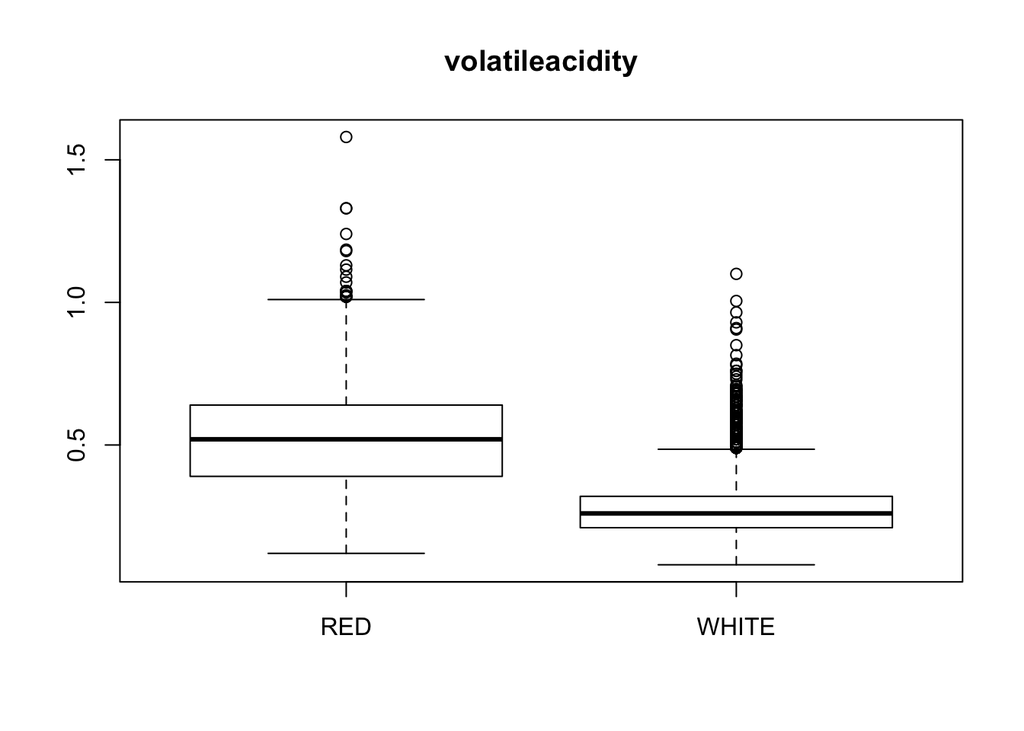

```r
boxplot(volatileacidity ~ Vinho , main='volatileacidity')
```

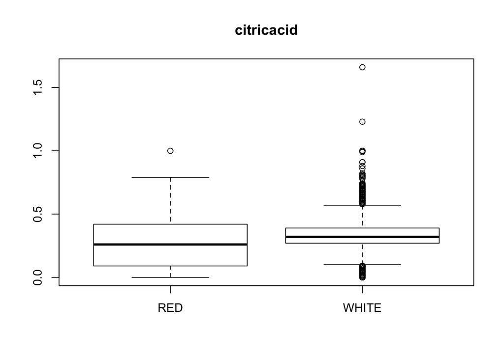

```r
boxplot(citricacid ~ Vinho, main='citricacid')
```

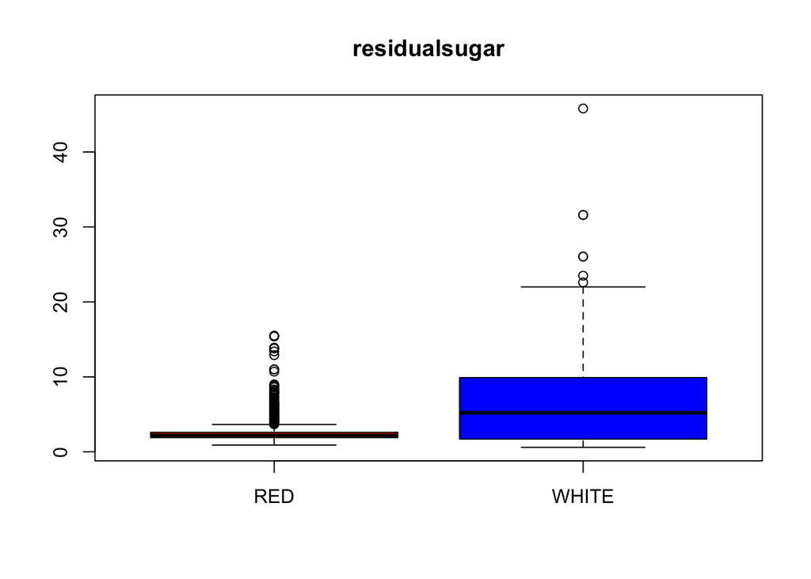

```r
boxplot(residualsugar ~ Vinho, main='residualsugar',col=c('red','blue'))
```

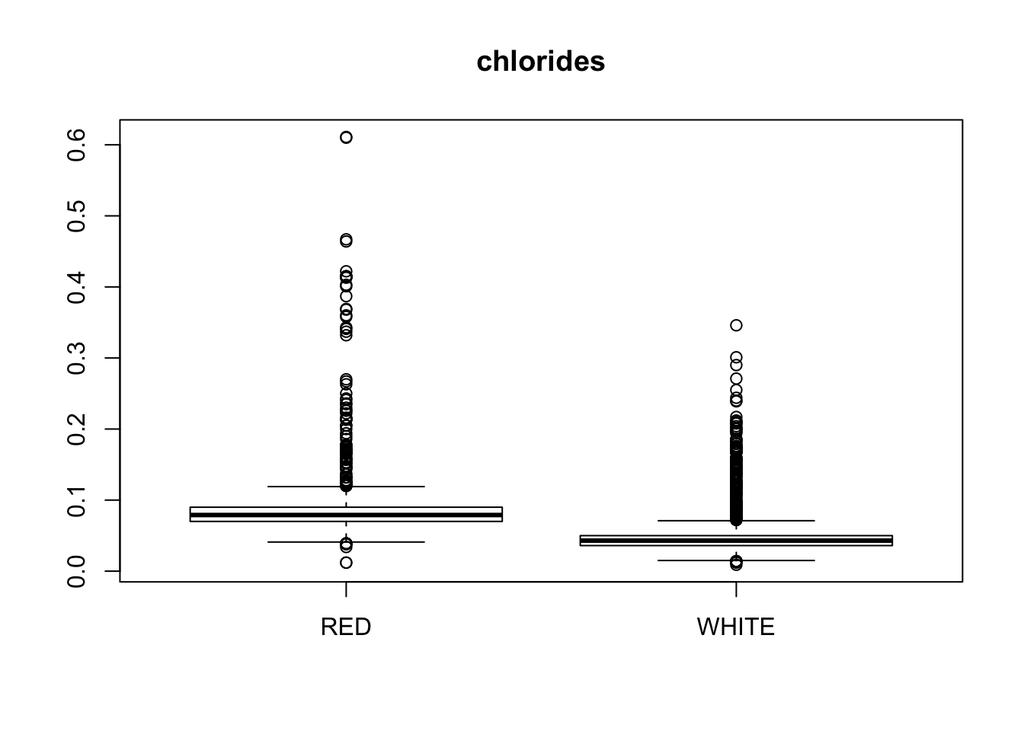

```r
boxplot(chlorides ~ Vinho, main='chlorides')
```

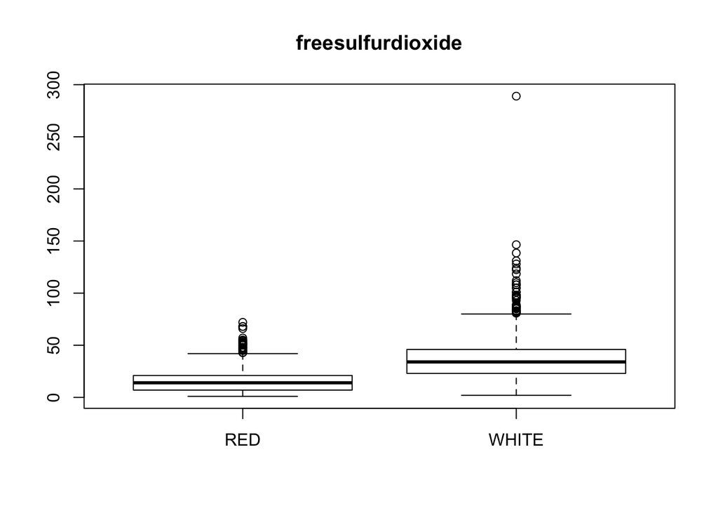

```r
boxplot(freesulfurdioxide ~ Vinho, main='freesulfurdioxide')
```

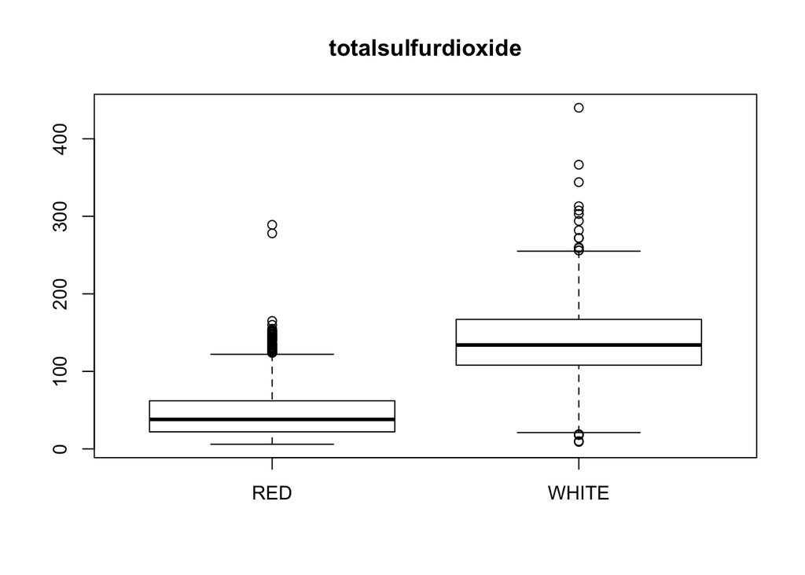

```r
boxplot(totalsulfurdioxide ~ Vinho, main='totalsulfurdioxide')
```

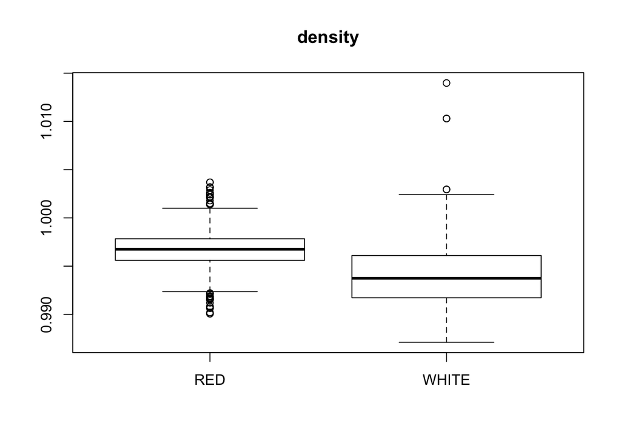

```r
boxplot(density ~ Vinho, main='density')
```

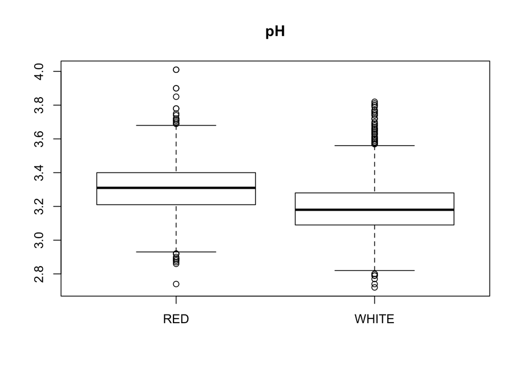

```r
boxplot(pH ~ Vinho, main='pH')
```

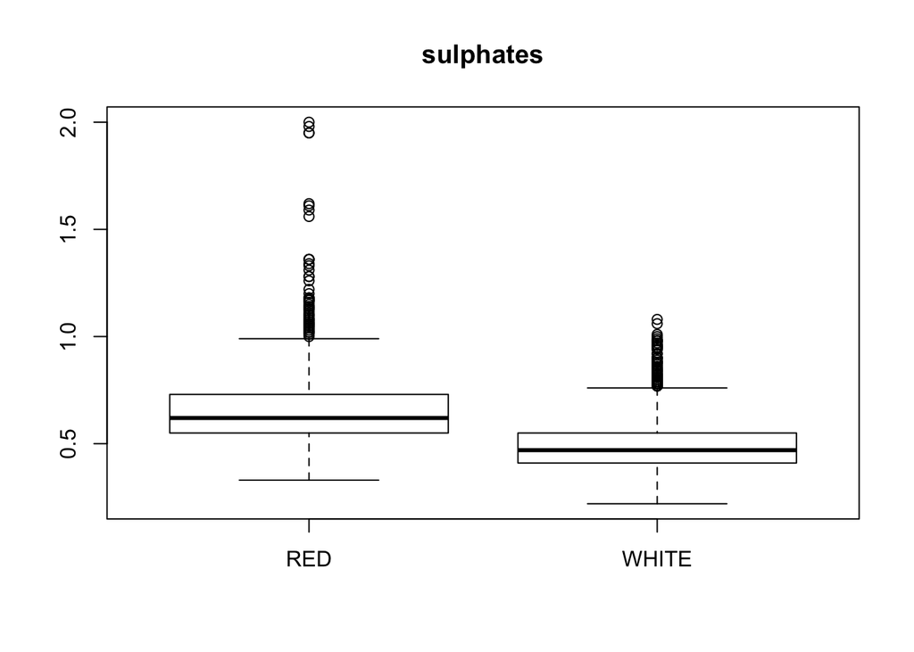

```r
boxplot(sulphates ~ Vinho, main='sulphates')
```

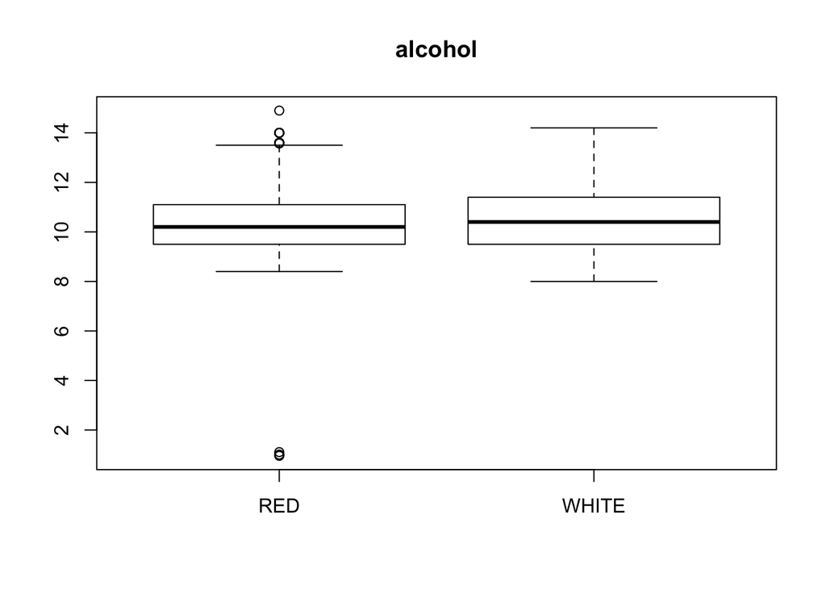

```r
boxplot(alcohol ~ Vinho, main='alcohol')
```

Análise:

Os Box Plots para todas as características, agora comparando os vinhos brancos e tintos podem servir para entender características que podem distinguir entre estes dois tipos e vinhos, como já fizemos com a quality, usando o teste de hipótese.

Olhando os Box Plots, outras características que podem ser diferentes por tipo de vinho são: volatileacidity, chlorides, freesulfurdioxide e totalsulfurdioxide (já comentado nas estatísticas descritivas)

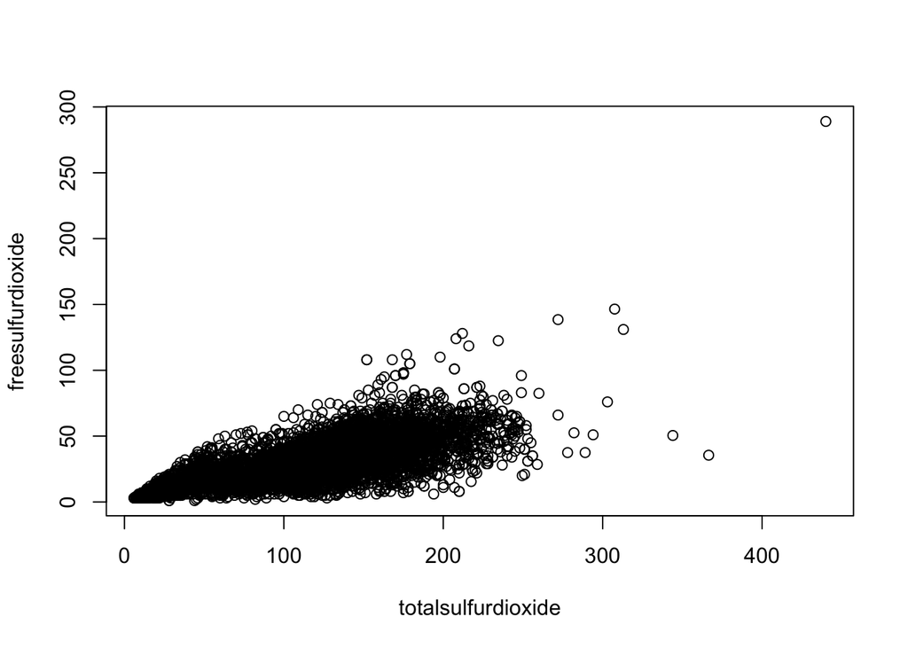

```r
# Gr·fico de dispers„o ( pch=caracter, lwd=largura)

plot(freesulfurdioxide~totalsulfurdioxide)
```

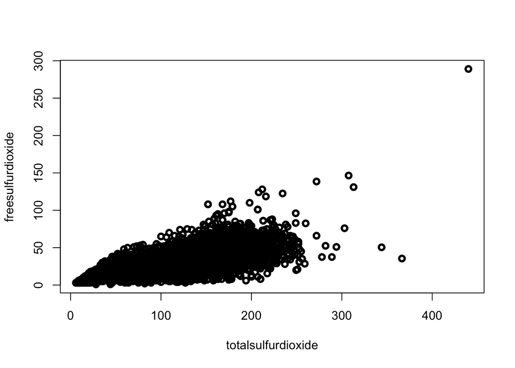

```r
plot(freesulfurdioxide~totalsulfurdioxide, pch=1, lwd=3)
```

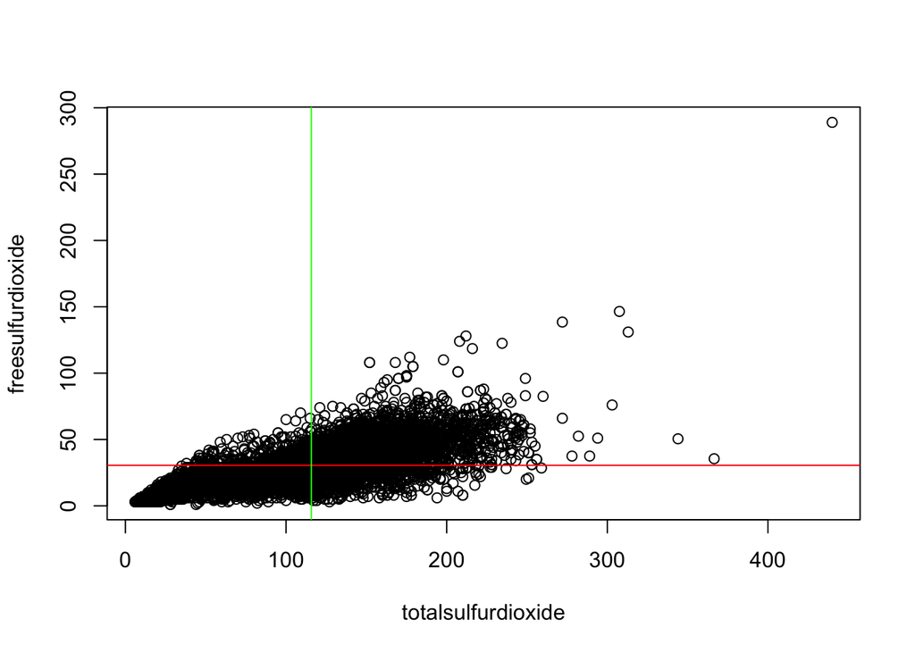

```r
plot(freesulfurdioxide~totalsulfurdioxide)
abline(h=mean(freesulfurdioxide), col="red")
abline(v=mean(totalsulfurdioxide), col="green")
```

Análise:

O Gráfico de dispersão mostra a relação de previsão entre as variáveis. Neste caso entre freesulfurdioxide e totalsulfurdioxide.

A linha verde representa a média do totalsulfurdioxide e a vermelha a média do freesulfurdioxide. O ponto onde onde as retas se encontram é um dos pontos que fará parte da regressão linear entre as variáveis e da uma ideia de centramento desta relação

```r
attach(Vinhos)
Vinhos$fx_redSugar <- cut(residualsugar,breaks=c(0,10,20,30,max(residualsugar)))
Vinhos$fx_redSugar
```

[output not shown]

[output cut: 1069 more lines]

```r
str(Vinhos)
```

```
## 'data.frame':    6497 obs. of  14 variables:
##  $ fixedacidity      : num  6.6 6.7 10.6 5.4 6.7 6.8 6.6 7.2 5.1 6.2 ...
##  $ volatileacidity   : num  0.24 0.34 0.31 0.18 0.3 0.5 0.61 0.66 0.26 0.22 ...
##  $ citricacid        : num  0.35 0.43 0.49 0.24 0.44 0.11 0 0.33 0.33 0.2 ...
##  $ residualsugar     : num  7.7 1.6 2.2 4.8 18.8 ...
##  $ chlorides         : num  0.031 0.041 0.063 0.041 0.057 0.075 0.069 0.068 0.027 0.035 ...
##  $ freesulfurdioxide : num  36 29 18 30 65 16 4 34 46 58 ...
##  $ totalsulfurdioxide: num  135 114 40 113 224 49 8 102 113 184 ...
##  $ density           : num  0.994 0.99 0.998 0.994 1 ...
##  $ pH                : num  3.19 3.23 3.14 3.42 3.11 3.36 3.33 3.27 3.35 3.11 ...
##  $ sulphates         : num  0.37 0.44 0.51 0.4 0.53 0.79 0.37 0.78 0.43 0.53 ...
##  $ alcohol           : num  10.5 12.6 9.8 9.4 9.1 9.5 10.4 12.8 11.4 9 ...
##  $ quality           : int  5 6 6 6 5 5 4 6 7 6 ...
##  $ Vinho             : Factor w/ 2 levels "RED","WHITE": 2 2 1 2 2 1 1 1 2 2 ...
##  $ fx_redSugar       : Factor w/ 4 levels "(0,10]","(10,20]",..: 1 1 1 1 2 1 1 1 1 3 ...
```

```r
CrossTable( Vinhos$fx_redSugar , Vinhos$Vinho)
```

```
##
##
##    Cell Contents
## |-------------------------|
## |                       N |
## | Chi-square contribution |
## |           N / Row Total |
## |           N / Col Total |
## |         N / Table Total |
## |-------------------------|
##
##
## Total Observations in Table:  6497
##
##
##                    | Vinhos$Vinho
## Vinhos$fx_redSugar |       RED |     WHITE | Row Total |
## -------------------|-----------|-----------|-----------|
##             (0,10] |      1588 |      3705 |      5293 |
##                    |    62.493 |    20.401 |           |
##                    |     0.300 |     0.700 |     0.815 |
##                    |     0.993 |     0.756 |           |
##                    |     0.244 |     0.570 |           |
## -------------------|-----------|-----------|-----------|
##            (10,20] |        11 |      1175 |      1186 |
##                    |   270.305 |    88.244 |           |
##                    |     0.009 |     0.991 |     0.183 |
##                    |     0.007 |     0.240 |           |
##                    |     0.002 |     0.181 |           |
## -------------------|-----------|-----------|-----------|
##            (20,30] |         0 |        15 |        15 |
##                    |     3.692 |     1.205 |           |
##                    |     0.000 |     1.000 |     0.002 |
##                    |     0.000 |     0.003 |           |
##                    |     0.000 |     0.002 |           |
## -------------------|-----------|-----------|-----------|
##          (30,45.8] |         0 |         3 |         3 |
##                    |     0.738 |     0.241 |           |
##                    |     0.000 |     1.000 |     0.000 |
##                    |     0.000 |     0.001 |           |
##                    |     0.000 |     0.000 |           |
## -------------------|-----------|-----------|-----------|
##       Column Total |      1599 |      4898 |      6497 |
##                    |     0.246 |     0.754 |           |
## -------------------|-----------|-----------|-----------|
##
##
```

Análise:

Olahndo os intervalos de resíduos de açucar (faixas de 10 em 10), podemos ver que a maior concentração esta na faixa entre 0 e 10 (81,5%)

O mesmo comprtamento se aplica se olharmos por tipo de vinho: Brancos (75,6%) e tintos (99,3%). O que indica que os vinhos tintos tem menos açucar, pois sua concentração esta na faixa de 0 a 10 (faixa inicial) de concentração de resíduo de açucar. E os brancos apresentam maiores concetrações nas faixas superiores: Faixa de 10 a 20, Brancos (24%) x Tintos (0,7%)

```r
attach(Vinhos)
library(psych)
describe(Vinhos)
```

```
##                    vars    n   mean    sd median trimmed   mad  min    max
## fixedacidity          1 6497   7.22  1.30   7.00    7.06  0.89 3.80  15.90
## volatileacidity       2 6497   0.34  0.16   0.29    0.32  0.12 0.08   1.58
## citricacid            3 6497   0.32  0.15   0.31    0.32  0.10 0.00   1.66
## residualsugar         4 6497   5.44  4.73   3.00    4.70  2.52 0.60  45.80
## chlorides             5 6497   0.06  0.04   0.05    0.05  0.02 0.01   0.61
## freesulfurdioxide     6 6497  30.53 17.75  29.00   29.32 17.79 1.00 289.00
## totalsulfurdioxide    7 6497 115.74 56.52 118.00  115.92 57.82 6.00 440.00
## density               8 6497   0.99  0.00   0.99    0.99  0.00 0.99   1.01
## pH                    9 6497   3.22  0.16   3.21    3.21  0.16 2.72   4.01
## sulphates            10 6497   0.53  0.15   0.51    0.52  0.12 0.22   2.00
## alcohol              11 6497  10.49  1.22  10.30   10.40  1.33 0.96  14.90
## quality              12 6497   5.82  0.87   6.00    5.79  1.48 3.00   9.00
## Vinho*               13 6497   1.75  0.43   2.00    1.82  0.00 1.00   2.00
## fx_redSugar*         14 6497   1.19  0.40   1.00    1.11  0.00 1.00   4.00
##                     range  skew kurtosis   se
## fixedacidity        12.10  1.72     5.05 0.02
## volatileacidity      1.50  1.49     2.82 0.00
## citricacid           1.66  0.47     2.39 0.00
## residualsugar       45.20  1.24     1.28 0.06
## chlorides            0.60  5.40    50.84 0.00
## freesulfurdioxide  288.00  1.22     7.90 0.22
## totalsulfurdioxide 434.00  0.00    -0.37 0.70
## density              0.03  0.05    -0.32 0.00
## pH                   1.29  0.39     0.37 0.00
## sulphates            1.78  1.80     8.64 0.00
## alcohol             13.94  0.26     1.56 0.02
## quality              6.00  0.19     0.23 0.01
## Vinho*               1.00 -1.18    -0.61 0.01
## fx_redSugar*         3.00  1.81     2.20 0.00
```

```r
# describe
# A data.frame of the relevant statistics:
# item name
# item number
# number of valid cases
# mean
# standard deviation
# trimmed mean (with trim defaulting to .1)
# median (standard or interpolated
# mad: median absolute deviation (from the median)
# minimum
# maximum
# skew
# kurtosis
# standard error


summary(Vinhos)
```

```
##   fixedacidity    volatileacidity    citricacid     residualsugar
##  Min.   : 3.800   Min.   :0.0800   Min.   :0.0000   Min.   : 0.60
##  1st Qu.: 6.400   1st Qu.:0.2300   1st Qu.:0.2500   1st Qu.: 1.80
##  Median : 7.000   Median :0.2900   Median :0.3100   Median : 3.00
##  Mean   : 7.215   Mean   :0.3397   Mean   :0.3186   Mean   : 5.44
##  3rd Qu.: 7.700   3rd Qu.:0.4000   3rd Qu.:0.3900   3rd Qu.: 8.10
##  Max.   :15.900   Max.   :1.5800   Max.   :1.6600   Max.   :45.80
##    chlorides       freesulfurdioxide totalsulfurdioxide    density
##  Min.   :0.00900   Min.   :  1.00    Min.   :  6.0      Min.   :0.9871
##  1st Qu.:0.03800   1st Qu.: 17.00    1st Qu.: 77.0      1st Qu.:0.9923
##  Median :0.04700   Median : 29.00    Median :118.0      Median :0.9949
##  Mean   :0.05603   Mean   : 30.53    Mean   :115.7      Mean   :0.9947
##  3rd Qu.:0.06500   3rd Qu.: 41.00    3rd Qu.:156.0      3rd Qu.:0.9970
##  Max.   :0.61100   Max.   :289.00    Max.   :440.0      Max.   :1.0140
##        pH          sulphates         alcohol           quality
##  Min.   :2.720   Min.   :0.2200   Min.   : 0.9567   Min.   :3.000
##  1st Qu.:3.110   1st Qu.:0.4300   1st Qu.: 9.5000   1st Qu.:5.000
##  Median :3.210   Median :0.5100   Median :10.3000   Median :6.000
##  Mean   :3.219   Mean   :0.5313   Mean   :10.4862   Mean   :5.818
##  3rd Qu.:3.320   3rd Qu.:0.6000   3rd Qu.:11.3000   3rd Qu.:6.000
##  Max.   :4.010   Max.   :2.0000   Max.   :14.9000   Max.   :9.000
##    Vinho         fx_redSugar
##  RED  :1599   (0,10]   :5293
##  WHITE:4898   (10,20]  :1186
##               (20,30]  :  15
##               (30,45.8]:   3
##
##
```

```r
white <- subset(Vinhos, Vinho=="WHITE", select=c(quality,fixedacidity,volatileacidity,citricacid,residualsugar,
                                                 chlorides,freesulfurdioxide,totalsulfurdioxide,density,pH,
                                                 sulphates,alcohol))
```

Análise:

Criamos um Dataset para os vinhos Brancos, com todas as variáveis usadas anteriormente

```r
#EstatÌsticas descritivas
summary(white)
```

```
##     quality       fixedacidity    volatileacidity    citricacid
##  Min.   :3.000   Min.   : 3.800   Min.   :0.0800   Min.   :0.0000
##  1st Qu.:5.000   1st Qu.: 6.300   1st Qu.:0.2100   1st Qu.:0.2700
##  Median :6.000   Median : 6.800   Median :0.2600   Median :0.3200
##  Mean   :5.878   Mean   : 6.855   Mean   :0.2782   Mean   :0.3342
##  3rd Qu.:6.000   3rd Qu.: 7.300   3rd Qu.:0.3200   3rd Qu.:0.3900
##  Max.   :9.000   Max.   :14.200   Max.   :1.1000   Max.   :1.6600
##  residualsugar      chlorides       freesulfurdioxide totalsulfurdioxide
##  Min.   : 0.600   Min.   :0.00900   Min.   :  2.00    Min.   :  9.0
##  1st Qu.: 1.700   1st Qu.:0.03600   1st Qu.: 23.00    1st Qu.:108.0
##  Median : 5.200   Median :0.04300   Median : 34.00    Median :134.0
##  Mean   : 6.387   Mean   :0.04577   Mean   : 35.31    Mean   :138.4
##  3rd Qu.: 9.900   3rd Qu.:0.05000   3rd Qu.: 46.00    3rd Qu.:167.0
##  Max.   :45.800   Max.   :0.34600   Max.   :289.00    Max.   :440.0
##     density             pH          sulphates         alcohol
##  Min.   :0.9871   Min.   :2.720   Min.   :0.2200   Min.   : 8.00
##  1st Qu.:0.9917   1st Qu.:3.090   1st Qu.:0.4100   1st Qu.: 9.50
##  Median :0.9937   Median :3.180   Median :0.4700   Median :10.40
##  Mean   :0.9940   Mean   :3.188   Mean   :0.4898   Mean   :10.51
##  3rd Qu.:0.9961   3rd Qu.:3.280   3rd Qu.:0.5500   3rd Qu.:11.40
##  Max.   :1.0140   Max.   :3.820   Max.   :1.0800   Max.   :14.20
```

```r
str(white)
```

```
## 'data.frame':    4898 obs. of  12 variables:
##  $ quality           : int  5 6 6 5 7 6 5 6 6 6 ...
##  $ fixedacidity      : num  6.6 6.7 5.4 6.7 5.1 6.2 6.6 7.3 6.7 6.2 ...
##  $ volatileacidity   : num  0.24 0.34 0.18 0.3 0.26 0.22 0.25 0.27 0.26 0.12 ...
##  $ citricacid        : num  0.35 0.43 0.24 0.44 0.33 0.2 0.36 0.37 0.29 0.26 ...
##  $ residualsugar     : num  7.7 1.6 4.8 18.8 1.1 ...
##  $ chlorides         : num  0.031 0.041 0.041 0.057 0.027 0.035 0.045 0.042 0.038 0.044 ...
##  $ freesulfurdioxide : num  36 29 30 65 46 58 54 36 40 56 ...
##  $ totalsulfurdioxide: num  135 114 113 224 113 184 180 130 179 158 ...
##  $ density           : num  0.994 0.99 0.994 1 0.989 ...
##  $ pH                : num  3.19 3.23 3.42 3.11 3.35 3.11 3.08 3.48 3.23 3.52 ...
##  $ sulphates         : num  0.37 0.44 0.4 0.53 0.43 0.53 0.42 0.75 0.56 0.37 ...
##  $ alcohol           : num  10.5 12.6 9.4 9.1 11.4 9 9.2 9.9 10.4 10.5 ...
```

Análise:

```r
attach(white)
```

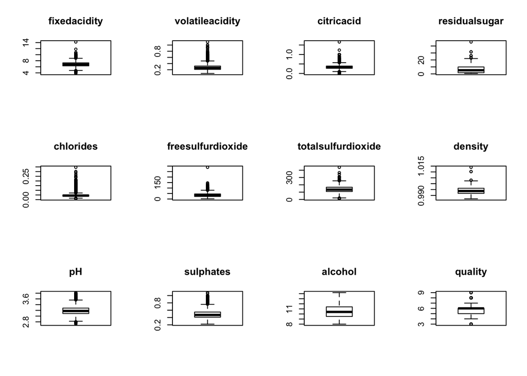

```r
#EstatÌsticas descritivas

par (mfrow=c(3,4))
boxplot(fixedacidity, main='fixedacidity')
boxplot(volatileacidity , main='volatileacidity')
boxplot(citricacid , main='citricacid')
boxplot(residualsugar, main='residualsugar')
boxplot(chlorides, main='chlorides')
boxplot(freesulfurdioxide, main='freesulfurdioxide')
boxplot(totalsulfurdioxide, main='totalsulfurdioxide')
boxplot(density, main='density')
boxplot(pH, main='pH')
boxplot(sulphates, main='sulphates')
boxplot(alcohol, main='alcohol')
boxplot(quality, main='quality')
```

Análise:

Todos os Box Plots dos vinhos brancos apresentarem Outliers (exceto a variavel alcohol), que pode ser efeito dos tamanhos de amostra, os BoxPlots com maiores quantidade de outliers são: volatileacidity, citricacid, chlorides, freesulfurdioxide, citricacid e freesulfurdioxide com valores pontuais bem distantes da distribuição. Valeria uma melhor avaliação destes pontos de medidas para verificação se realmente são pontos fora da curva esperada.

Distribuições assimetricas, com principal atenção para residualsugar, onde a assimentria se destaca na forma da caixa de dos bigodes do Box Plot. Mediana deslocada para o Q1 e bigode inferior bem menor que o superior.

```r
boxplot.stats(white$residualsugar)
```

```
## $stats
## [1]  0.6  1.7  5.2  9.9 22.0
##
## $n
## [1] 4898
##
## $conf
## [1] 5.014877 5.385123
##
## $out
## [1] 26.05 31.60 22.60 45.80 31.60 26.05 23.50
```

```r
AIQ_residualsugar<-quantile(white$residualsugar,.75,type=2)-quantile(white$residualsugar,.25,type=2)
AIQ_residualsugar
```

```
## 75%
## 8.2
```

```r
limsup_residualsugar= quantile(white$residualsugar,.75,type=4)+1.5*AIQ_residualsugar
limsup_residualsugar
```

```
##  75%
## 22.2
```

```r
liminf_residualsugar= quantile(white$residualsugar,.25,type=2)-1.5*AIQ_residualsugar
liminf_residualsugar
```

```
##   25%
## -10.6
```

Análise:

Sobre as estatísticas do BoxPlot (boxplot.stat) podemos dizer: - O bigode inferiro = valor mínimo (0,6), os qurtis Q1 = 1,7 e Q2 (mediana) = 5,2 e Q3 = 9,9. O bigode superior = 22,0. Como temos valores maiores que o 22,0, teremos outliers acima de 22,0. Mostrado no $out. - Os valores do $conf, são (segundo Chambers e McGill) aproximadamente o intervalo de confiança para a mediana.

Temos também a amplitude entre quartis: Q3 - Q1 = 8,2

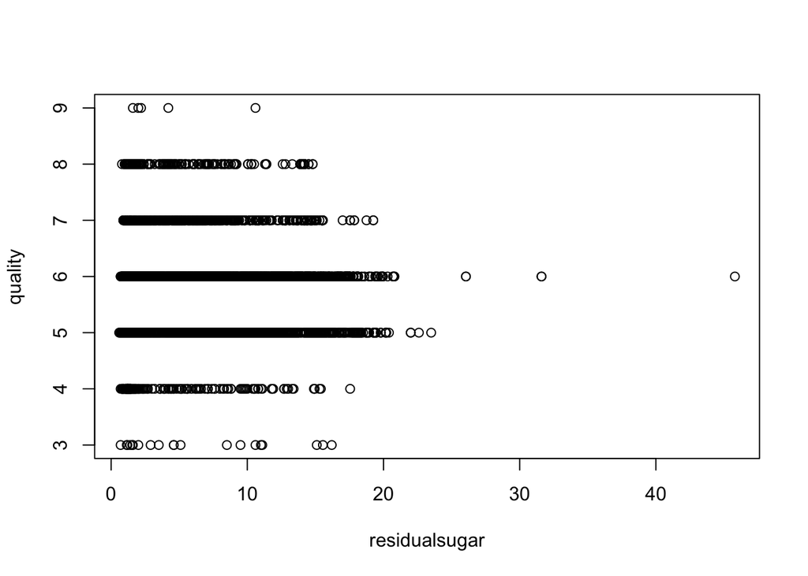

```r
#excluir outliers

plot(quality~residualsugar)
```

```r
white1<-subset(white, residualsugar<=22.2)

#fix(white1)
```

Análise:

Analisando o gráfico do residuo de açucar (resildualsugar) x nota de qualidade dos vinhos brancos (quality), podemos perceber uma maior concentração de resíduos de açucar para os vinhos com notas entre 5 e 6

```r
attach(white1)
summary(white1)
```

```
##     quality       fixedacidity    volatileacidity   citricacid
##  Min.   :3.000   Min.   : 3.800   Min.   :0.080   Min.   :0.0000
##  1st Qu.:5.000   1st Qu.: 6.300   1st Qu.:0.210   1st Qu.:0.2700
##  Median :6.000   Median : 6.800   Median :0.260   Median :0.3200
##  Mean   :5.878   Mean   : 6.854   Mean   :0.278   Mean   :0.3341
##  3rd Qu.:6.000   3rd Qu.: 7.300   3rd Qu.:0.320   3rd Qu.:0.3900
##  Max.   :9.000   Max.   :14.200   Max.   :1.100   Max.   :1.6600
##  residualsugar      chlorides       freesulfurdioxide totalsulfurdioxide
##  Min.   : 0.600   Min.   :0.00900   Min.   :  2.00    Min.   :  9.0
##  1st Qu.: 1.700   1st Qu.:0.03600   1st Qu.: 23.00    1st Qu.:108.0
##  Median : 5.200   Median :0.04300   Median : 34.00    Median :134.0
##  Mean   : 6.354   Mean   :0.04575   Mean   : 35.31    Mean   :138.3
##  3rd Qu.: 9.850   3rd Qu.:0.05000   3rd Qu.: 46.00    3rd Qu.:167.0
##  Max.   :22.000   Max.   :0.34600   Max.   :289.00    Max.   :440.0
##     density             pH          sulphates         alcohol
##  Min.   :0.9871   Min.   :2.720   Min.   :0.2200   Min.   : 8.00
##  1st Qu.:0.9917   1st Qu.:3.090   1st Qu.:0.4100   1st Qu.: 9.50
##  Median :0.9937   Median :3.180   Median :0.4700   Median :10.40
##  Mean   :0.9940   Mean   :3.188   Mean   :0.4899   Mean   :10.51
##  3rd Qu.:0.9961   3rd Qu.:3.280   3rd Qu.:0.5500   3rd Qu.:11.40
##  Max.   :1.0024   Max.   :3.820   Max.   :1.0800   Max.   :14.20
```

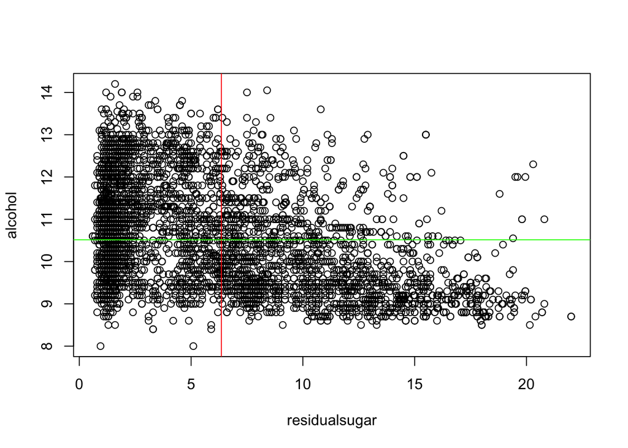

```r
plot(residualsugar,alcohol)
abline(v=mean(residualsugar), col="red")
abline(h=mean(alcohol), col="green")
```

Análise:

Após tirarmos o valor de residualsugar acima de 22,2 (limite do bigode do BoxPlot), podemos analisar que existe uma correlação negativa entre as variáveis, ou seja quanto maior o teor alcolico, menor a concentração de resíduo de açucar, com exceção de valores de baixo resíduo de açucar e baixa quantidade de alcool, que possivelmente pode ser explicado por não ter açucar suficiente no início do processo (suco de uva) e que não provoca uma fermentação que eleve o nível de alcool no vinho.

Ainda observando que estes valores de residuo de açucar baixo e alcool baixo, reduzem os valores de média para as duas variáveis, podendo enviezar a interpretação de uma futura análise de regressão.

```r
# matriz de correlaÁıes
matcor <- cor(white1)
print(matcor, digits = 2)
```

```
##                    quality fixedacidity volatileacidity citricacid
## quality             1.0000       -0.114         -0.1963    -0.0088
## fixedacidity       -0.1141        1.000         -0.0248     0.2895
## volatileacidity    -0.1963       -0.025          1.0000    -0.1529
## citricacid         -0.0088        0.290         -0.1529     1.0000
## residualsugar      -0.0995        0.087          0.0460     0.0914
## chlorides          -0.2095        0.023          0.0700     0.1132
## freesulfurdioxide   0.0088       -0.049         -0.0949     0.0943
## totalsulfurdioxide -0.1746        0.091          0.0892     0.1207
## density            -0.3176        0.268          0.0032     0.1483
## pH                  0.0991       -0.427         -0.0334    -0.1643
## sulphates           0.0535       -0.017         -0.0379     0.0616
## alcohol             0.4363       -0.120          0.0673    -0.0765
##                    residualsugar chlorides freesulfurdioxide
## quality                   -0.100    -0.210           0.00876
## fixedacidity               0.087     0.023          -0.04884
## volatileacidity            0.046     0.070          -0.09485
## citricacid                 0.091     0.113           0.09425
## residualsugar              1.000     0.086           0.30987
## chlorides                  0.086     1.000           0.10095
## freesulfurdioxide          0.310     0.101           1.00000
## totalsulfurdioxide         0.408     0.199           0.61591
## density                    0.831     0.261           0.30898
## pH                        -0.199    -0.091           0.00018
## sulphates                 -0.028     0.017           0.06009
## alcohol                   -0.462    -0.362          -0.25022
##                    totalsulfurdioxide density       pH sulphates alcohol
## quality                       -0.1746 -0.3176  0.09913     0.053   0.436
## fixedacidity                   0.0905  0.2682 -0.42667    -0.017  -0.120
## volatileacidity                0.0892  0.0032 -0.03342    -0.038   0.067
## citricacid                     0.1207  0.1483 -0.16430     0.062  -0.077
## residualsugar                  0.4081  0.8315 -0.19916    -0.028  -0.462
## chlorides                      0.1990  0.2613 -0.09063     0.017  -0.362
## freesulfurdioxide              0.6159  0.3090  0.00018     0.060  -0.250
## totalsulfurdioxide             1.0000  0.5436  0.00274     0.135  -0.448
## density                        0.5436  1.0000 -0.09845     0.075  -0.806
## pH                             0.0027 -0.0984  1.00000     0.155   0.121
## sulphates                      0.1348  0.0748  0.15517     1.000  -0.018
## alcohol                       -0.4484 -0.8064  0.12103    -0.018   1.000
```

Análise:

Observando as correlações, algumas nos chamam a atenção: - residualsugar x density = 0,8315, que comprova que vinhos com muito açucar tem maior densidade, no sentido inverso; - vinhos com muito alcool tem menor densidade (correlação = -0,8064). - forte correlação entre freesulfurdioxide x totalsulfurdioxide (0,61591), devido ao livre fazer parte do total deste conservante.

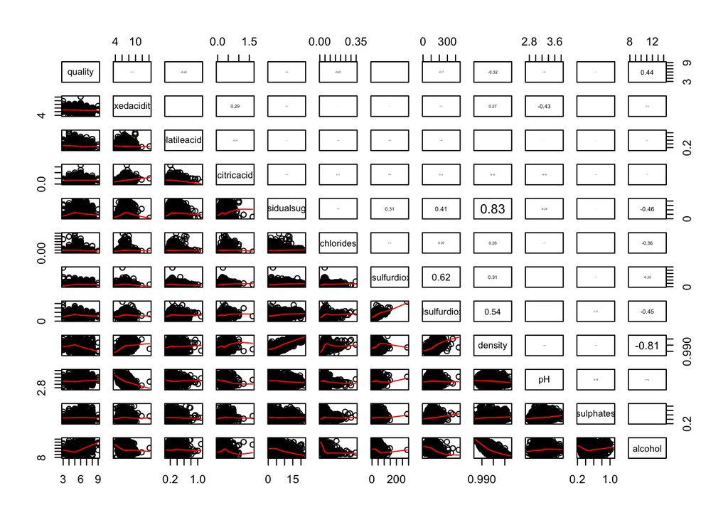

```r
#library(corrgram)
#corrgram(matcor, type = "cor", lower.panel = panel.shade, upper.panel = panel.pie)

panel.cor <- function(x, y, digits=2, prefix ="", cex.cor,
                      ...)  {
  usr <- par("usr")
  on.exit(par(usr))
  par(usr = c(0, 1, 0, 1))
  r <- cor(x, y , use = "pairwise.complete.obs")
  txt <- format(c(r, 0.123456789), digits = digits) [1]
  txt <- paste(prefix, txt, sep = "")
  if (missing(cex.cor))
    cex <- 0.8/strwidth(txt)
  # abs(r) È para que na saÌda as correlaÁıes ficam proporcionais
  text(0.5, 0.5, txt, cex = cex * abs(r))
}
#pdf(file = "grafico.pdf")
pairs(white1, lower.panel=panel.smooth, upper.panel=panel.cor)
```

Análise:

Agora podemos comprovar atraves de gráficos o que já foi comentado a análise da tabela de correlação